# Analysis of Fatal Police Shootings (2015 - 2016)

### Exploring the Data

Pandas provides a lot of nice helpers functions to obtain useful information about the dataset. Let's take a look at some of them in the context of the dataframe we've created and named df .

##### Head df.head( n = 5 ) returns rows from dataframe from first valid index to that index + n

```python
df.head(n=3)
```

|  | uid | name | age | gender | raceethnicity | armed | month | day | year | streetaddress | city | state | classification | lawenforcementagency |
| --- | --- | --- | --- | --- | --- | --- | --- | --- | --- | --- | --- | --- | --- | --- |
| 0 | 2 | Matthew Ajibade | 22 | Male | Black | No | January | 1 | 2015 | 1050 Carl Griffin Dr | Savannah | GA | Death in custody | Chatham County Sheriff's Office |
| 1 | 4 | Lewis Lembke | 47 | Male | White | Firearm | January | 2 | 2015 | 4505 SW Masters Loop | Aloha | OR | Gunshot | Washington County Sheriff's Office |
| 2 | 5 | Michael Kocher Jr | 19 | Male | White | No | January | 3 | 2015 | 2600 Kaumualii Hwy | Kaumakani | HI | Struck by vehicle | Kauai Police Department |

##### Tail df.tail(n=5) returns rows from dataframe from last valid index to that index - n

```python
df.tail(n=3)
```

|  | uid | name | age | gender | raceethnicity | armed | month | day | year | streetaddress | city | state | classification | lawenforcementagency |
| --- | --- | --- | --- | --- | --- | --- | --- | --- | --- | --- | --- | --- | --- | --- |
| 2223 | 20161088 | Jamal Rollins | 21 | Male | Black | Disputed | December | 30 | 2016 | 10100 W Indigo St | Miami | FL | Gunshot | Miami-Dade Police Department |
| 2224 | 20161089 | Unknown | Unknown | Male | Unknown | Knife | December | 31 | 2016 | 13000 Compton Rd | Loxahatchee Groves | FL | Gunshot | Palm Beach County Sheriff's Office |
| 2225 | 20161090 | Jason Robison | 32 | Male | White | Unknown | December | 31 | 2016 | NaN | Hesston | PA | Gunshot | Pennsylvania State Police |

##### Size

So you probably want a simple way to figure out the number of rows in your dataframe. Here are some acceptable ways to do it followed by the wrong way.

```python
right_way_1 = df.shape[0]
right_way_2 = len(df)
right_way_3 = df.index.size
wrong_way = df.size

print("right_way_1: ", right_way_1)
print("right_way_2: ", right_way_2)
print("right_way_3: ", right_way_3)
print()
print("wrong: ", wrong_way)
```

```
right_way_1:  2226
right_way_2:  2226
right_way_3:  2226

wrong:  31164
```

Since we're working with a dataframe and **not** a 1D array df.size tells you how many cells are in the dataframe. As we'll explore soon, this is the equivalent of df.shape[0] * df.shape[1].

##### Columns df.columns

```python
num_cols = len(df.columns)
column_names = df.columns.values
print(num_cols)
print(column_names)
```

```
14
['uid' 'name' 'age' 'gender' 'raceethnicity' 'armed' 'month' 'day' 'year'
 'streetaddress' 'city' 'state' 'classification' 'lawenforcementagency']
```

##### Shape df.shape

Here's another quick way to get the number of rows and columns of a dataframe, returning a tuple **(nrows, ncols)**.

```python
nrows, ncols = df.shape # same as (df.index.size, len(df.columns))
print("Number of rows: ", nrows)
print("Number of columns: ", ncols)
```

```
Number of rows:  2226
Number of columns:  14
```

##### Count df.count()

So one thing I like to do before I analyze the data is assess its quality. The most basic question to ask is whether all the data is actually present? One way determine this is to use df.count(), which returns the number of rows in each column that are filled. If all cells are filled, then the number of filled cells in each column should be the same, and their sum should equal df.size .

```python
count = df.count()
percent_present = sum(count) / df.size * 100
print(count)
print()
print("Percent: ", str(percent_present) + "%")
```

```
uid                     2226
name                    2226
age                     2226
gender                  2226
raceethnicity           2226
armed                   2226
month                   2226
day                     2226
year                    2226
streetaddress           2194
city                    2226
state                   2226
classification          2226
lawenforcementagency    2226
dtype: int64

Percent:  99.8973174175%
```

It looks like almost all the data is present. Only 32 street addresses are missing. This may seem like a nuisance, but in reality 99.897 % is way better than average, and pandas has ways accomodate potential issues.

##### Dtypes df.dtypes

Now that we know most of the data is **present**, the next question is whether the data is **consistent**. What does that mean?

We want to know if the data uses the same data types or dtypes to represent similar values. It's also good to know what those dtypes are and if they are what we want. For example, is January represented by a string "January" or by an integer 1? Are there spelling mistakes? Is there any weirdness in the data that exerts a false presence we want to get rid of such as null-like values or empty strings?

Let's address the consistency of the data by looking at the dtypes. Each column or *feature* uses the same dtype in all its values.

```python
df.dtypes
```

```
uid                      int64
name                    object
age                     object
gender                  object
raceethnicity           object
armed                   object
month                   object
day                      int64
year                     int64
streetaddress           object
city                    object
state                   object
classification          object
lawenforcementagency    object
dtype: object
```

Hmm, that doesn't feel very informative. It's saying that state and city are of type object, but it also says that of age.

It turns out that object means string.

```python
print(type(df.age.values[0]))
print(type(df.state.values[0]))
```

```
<class 'str'>
<class 'str'>
```

Do we want age to be a string?

It would make sense for age to be numerical if we wanted to answer questions like say, Are fatal shootings by police officers more likely to occur to young or old people? However, let's look at the age values themselves before we decide that it's appropriate.

##### Unique df.col.unique()

Since we only need to look at the unique values let's take advantage of pandas' unique() function. First I like to check that there aren't too many values to look at.

```python
df.age.unique().size
```

```
77
```

Ok, that's a lot more than I thought, but not overwhelming. Does this mean elderly people and children get shot by police officers? Let's take a look at the values themselves.

```python
df.age.unique()
```

```
array(['22', '47', '19', '23', '53', '32', '39', '25', '26', '34', '35',
       '30', '31', '37', '42', '28', '36', '49', '33', '71', '29', '43',
       '24', '68', '75', '87', '27', '48', '57', '69', '41', '21', '67',
       '45', '54', '17', '56', '61', '59', '44', '40', '18', '38', '51',
       '74', '46', '50', '20', 'Unknown', '16', '63', '62', '58', '64',
       '52', '60', '77', '83', '72', '76', '55', '66', '85', '15', '65',
       '6', '12', '10', '70', '80', '73', '14', '40s', '82', '86', '13',
       '84'], dtype=object)
```

So the lesson here is don't shy away from examining strings, because strings are the wild west when it comes to **consistency**. It looks like the only reason why age is represented by a string instead of an integer is because of unknowns, which could be represented instead by NaN or None. In that case, our df.count() would have accounted for the Unknowns, and our presence value would end up lower than 99.897%. Curiously, there is also a '40s', which is probably a typo.

I wonder if other features have Unknowns?

```python
def show_value(data, value):
    print("Number of {} in each column".format(value))
    for col in data.columns:
        if value in data[col].value_counts():
            print(col, ", ", data.age.value_counts()[value])
show_value(df, 'Unknown')
```

```
Number of Unknown in each column
name ,  15
age ,  15
raceethnicity ,  15
armed ,  15
streetaddress ,  15
lawenforcementagency ,  15
```

Looks like we have a lot of Unknowns. Now that we've identified some problems, let's clean this data up a little bit. First let's convert Unknown to None.

##### Replace df.replace()

Pandas' replace() takes a Series as its second argument.

```python
df_2 = df.replace('Unknown', df.replace(['Unknown'], [None]))
show_value(df_2, 'Unknown')
```

```
Number of Unknown in each column
```

Sweet, looks like we're no longer finding 'Unknown' in the data.

```python
df_2.isnull().sum()
```

```
uid                       0
name                     13
age                      15
gender                    0
raceethnicity            43
armed                   153
month                     0
day                       0
year                      0
streetaddress            36
city                      0
state                     0
classification            0
lawenforcementagency     21
dtype: int64
```

And the Unknowns were replaced with None values. Great. Now let's convert the age feature to a numerical type.

##### To Numeric to_numeric()

```python
df_2.age = pd.to_numeric(df.age, errors="coerce")
df_2.age.dtype
```

```
dtype('float64')
```

The errors="coerce" argument ensures that values unable to convert successfully become NaN. Great, let's check the data presence value again.

```python
percent_presence = sum(df_2.count()) / df_2.size * 100
print(str(percent_presence) + " %")
```

```
99.095109742 %
```

Wow, not even a 1% drop. Now we can determine how and if age is related to the liklihood of being fatally shot by a police officer.

##### Describedf.describe() or df.col.describe()

Pandas makes it easy to gather basic statistical facts about a Series or a DataFrame using the describe() function. Note that this would not work properly if the age feature was of type string.

```python
df_2.age.describe()
```

```
count    2210.000000
mean       36.927602
std        13.133614
min         6.000000
25%        27.000000
50%        35.000000
75%        45.000000
max        87.000000
Name: age, dtype: float64
```

The **count** is the number of values in the dataset.

The **mean** is the average age at roughly 37 years old.

The **std** or standard deviation indicates the average distance between a value and the mean. Therefore on average the difference between a value and the mean of all values is approximately 13.1 .

The percentages are quartiles. The 25% indicates that 25% of the people fatally shot by police officers were 27 years old or younger. The 75% indicates that 75% of the people fatally shot by police officers were 45 years old or younger.

The **min** signifies the youngest person shot at 6 years old.

The **max** signifies the oldest person shot at 87 years old.

Let's visualize this.

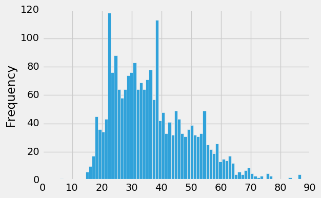

```python
plt.figure()
df_2.age.plot.hist(bins=df_2.age.unique().size)
```

It looks like you're more likely to get shot by a police officer and die if you're younger. Is this a reasonable conclusion to make?

Context matters. Let's explore that by asking a different question. </p>

### Is there any indication of ethnic discrimination in the data?

##### Group By df.groupby()

The most intuitive approach to answering this would be to figure out who gets shot and killed the most in the dataset. In order to figure that out we need some way to group the rows by raceethnicity. Fortunately, pandas makes this easy with the groupby() method.

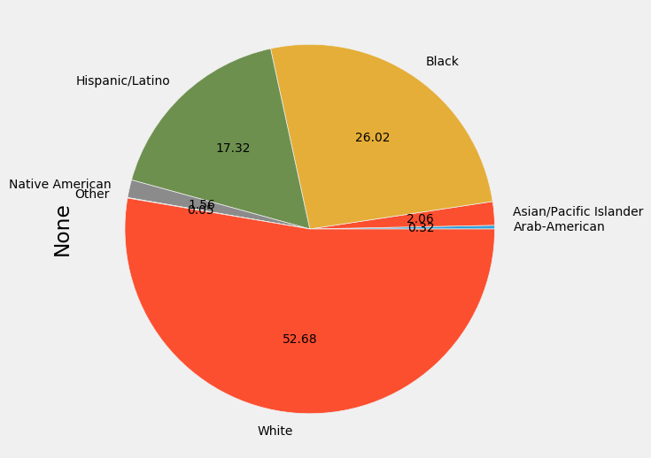

```python
#plt.figure()
plt.axis('equal')
df_2_ethnicity = df_2.groupby('raceethnicity').size()
labels = df_2_ethnicity.index
values = df_2_ethnicity.values
df_2_ethnicity.plot.pie(labels=labels, autopct='%.2f', figsize=(6,6), fontsize=10)
```

In order to answer this question we do need some more data. I was able to obtain a breakdown of state demographics by ethnicity from the US Census Bureau. The file sourced below has been formatted to ensure pandas doesn't run into problems converting to a dataframe.

```python
sd = pd.read_excel('data/state_demographics.xlsx', sheetname='Sheet1', thousands=',') # thousands argument removes commas from large numbers
sd = sd[sd['year'] == '2015 Estimate'] # we only care about population counts from 2015, not previous years
sd.head()
```

|  | state | year | total_population | one_race | white | black | asian | hispanic |
| --- | --- | --- | --- | --- | --- | --- | --- | --- |
| 0 | Alabama | 2015 Estimate | 4858979 | 98.2% | 68.5% | 26.8% | 1.2% | 4.0% |
| 9 | Alaska | 2015 Estimate | 738432 | 91.4% | 65.2% | 3.5% | 6.4% | 7.0% |
| 18 | Arizona | 2015 Estimate | 6828065 | 96.7% | 77.4% | 4.4% | 3.2% | 30.7% |
| 27 | Arkansas | 2015 Estimate | 2978204 | 97.8% | 77.5% | 15.8% | 1.4% | 7.0% |
| 36 | California | 2015 Estimate | 39144818 | 95.5% | 60.9% | 5.8% | 14.2% | 38.8% |

```python
percent_presence = "{} %".format(sum(sd.count()) / sd.size * 100)
print(percent_presence)
sd.dtypes
```

```
100.0 %
```

```
state               object
year                object
total_population    object
one_race            object
white               object
black               object
asian               object
hispanic            object
dtype: object
```

Uh ok, looks like our dtypes are all strings, but we want numerical values to be cast to floats. To do this we need to remove unwanted percent signs, cast string numbers to a numerical type, and then divide all the percentages by 100.

```python
# Remove percent symbols from sd values
sd.replace(regex=True, inplace=True, to_replace=r'(^.+)%', value=r'\1')

# In columns with numbers, convert to numeric
for col in sd.columns[2:]:
    sd[col] = pd.to_numeric(sd[col])

# In columns with percent values, divide values by 100
for col in sd.columns[3:]:
    sd[col] = sd[col] / 100

sd.dtypes
```

```
state                object
year                 object
total_population      int64
one_race            float64
white               float64
black               float64
asian               float64
hispanic            float64
dtype: object
```

Great, now we're ready to see how weighing the original data against state ethnicity demographics affects the results. So how do we even do that?

Currently we've defined the likelihood of a person having been fatally shot by a police officer belonging to a certain ethnicity as

$P_{eth} = \dfrac{D_{eth}}{D_T} x 100\%$.

- **Where,**
- $P_{eth}$ is the likelihood or probability of a person having been shot belonging to a certain ethnicity.
- $D_{eth}$ is the total number of deaths of an ethnicity.
- $D_{T}$ is the total number of deaths.

##### Matrix Multiplication

let $ D_{t^{[n,m]}} $ be an n by m matrix where $ D_{t^{[:,0]}} $ is a list of ethnicities and $ D_{t^{[:,1]}} $ is a vector of the number of death counts of each ethnicity in total.

```python
sd.head()
```

|  | state | year | total_population | one_race | white | black | asian | hispanic |
| --- | --- | --- | --- | --- | --- | --- | --- | --- |
| 0 | Alabama | 2015 Estimate | 4858979 | 0.982 | 0.685 | 0.268 | 0.012 | 0.040 |
| 9 | Alaska | 2015 Estimate | 738432 | 0.914 | 0.652 | 0.035 | 0.064 | 0.070 |
| 18 | Arizona | 2015 Estimate | 6828065 | 0.967 | 0.774 | 0.044 | 0.032 | 0.307 |
| 27 | Arkansas | 2015 Estimate | 2978204 | 0.978 | 0.775 | 0.158 | 0.014 | 0.070 |
| 36 | California | 2015 Estimate | 39144818 | 0.955 | 0.609 | 0.058 | 0.142 | 0.388 |

##### Loc df.loc()

```python
D_eth = df_2.ix[(df_2.raceethnicity == 'Black') & (df_2.state == 'AZ')].shape[0]
D_T = df_2.ix[df_2.state == 'AZ'].shape[0]
P_eth = sd.ix[sd.state == 'Arizona'].black.values[0]
(D_eth / D_T) * P_eth * 100
```

```
0.14193548387096774
```

```python
us_state_abbrev = {
    'Alabama': 'AL',
    'Alaska': 'AK',
    'Arizona': 'AZ',
    'Arkansas': 'AR',
    'California': 'CA',
    'Colorado': 'CO',
    'Connecticut': 'CT',
    'Delaware': 'DE',
    'Florida': 'FL',
    'Georgia': 'GA',
    'Hawaii': 'HI',
    'Idaho': 'ID',
    'Illinois': 'IL',
    'Indiana': 'IN',
    'Iowa': 'IA',
    'Kansas': 'KS',
    'Kentucky': 'KY',
    'Louisiana': 'LA',
    'Maine': 'ME',
    'Maryland': 'MD',
    'Massachusetts': 'MA',
    'Michigan': 'MI',
    'Minnesota': 'MN',
    'Mississippi': 'MS',
    'Missouri': 'MO',
    'Montana': 'MT',
    'Nebraska': 'NE',
    'Nevada': 'NV',
    'New Hampshire': 'NH',
    'New Jersey': 'NJ',
    'New Mexico': 'NM',
    'New York': 'NY',
    'North Carolina': 'NC',
    'North Dakota': 'ND',
    'Ohio': 'OH',
    'Oklahoma': 'OK',
    'Oregon': 'OR',
    'Pennsylvania': 'PA',
    'Rhode Island': 'RI',
    'South Carolina': 'SC',
    'South Dakota': 'SD',
    'Tennessee': 'TN',
    'Texas': 'TX',
    'Utah': 'UT',
    'Vermont': 'VT',
    'Virginia': 'VA',
    'Washington': 'WA',
    'West Virginia': 'WV',
    'Wisconsin': 'WI',
    'Wyoming': 'WY',
}
df_2_states = df_2.state.unique()
for state in us_state_abbrev:
    if us_state_abbrev[state] in df_2_states:
        df_2.replace(regex=True, inplace=True, to_replace=us_state_abbrev[state], value=state)
df_2.state.unique()
```

```
array(['Georgia', 'Oregon', 'Hawaii', 'Kansas', 'Washington', 'California',
       'Arizona', 'Colorado', 'Iowa', 'Pennsylvania', 'Illinois', 'Texas',
       'Louisiana', 'Nebraska', 'Montana', 'Arkansas', 'Utah', 'Nevada',
       'New Mexico', 'Minnesota', 'Missouri', 'New Jersey', 'New York',
       'Indiana', 'Virginia', 'Oklahoma', 'Kentucky', 'Massachusetts',
       'Mississippi', 'New Hampshire', 'Florida', 'Maryland', 'Idaho',
       'Ohio', 'Alaska', 'Tennessee', 'Michigan', 'North Carolina',
       'Maine', 'Alabama', 'Wisconsin', 'South Carolina', 'Delaware', 'DC',
       'West Virginia', 'Connecticut', 'Wyoming', 'North Dakota',
       'South Dakota', 'Rhode Island', 'Vermont'], dtype=object)
```

```python
size = sd.shape[0]
sd.loc[:, 'num_shot_white'] = np.zeros(size)
sd.loc[:, 'num_shot_black'] = np.zeros(size)
sd.loc[:, 'num_shot_hispanic'] = np.zeros(size)
sd.loc[:, 'total_deaths'] = np.zeros(size)
sd.loc[:, 'prob_shot_black'] = np.zeros(size)
sd.loc[:, 'prob_shot_white'] = np.zeros(size)
sd.loc[:, 'prob_shot_hispanic'] = np.zeros(size)

sd.head(1)
```

|  | state | year | total_population | one_race | white | black | asian | hispanic | num_shot_white | num_shot_black | num_shot_hispanic | total_deaths | prob_shot_black | prob_shot_white | prob_shot_hispanic |
| --- | --- | --- | --- | --- | --- | --- | --- | --- | --- | --- | --- | --- | --- | --- | --- |
| 0 | Alabama | 2015 Estimate | 4858979 | 0.982 | 0.685 | 0.268 | 0.012 | 0.04 | 0.0 | 0.0 | 0.0 | 0.0 | 0.0 | 0.0 | 0.0 |

```python
for row in sd.itertuples():
    if row.state in df_2_states:
        state = row.state
        deaths_by_ethnicity = df_2.ix[df_2.state == state].groupby('raceethnicity').size()
        D_T = deaths_by_ethnicity.sum()
        sd.loc[sd.state == state, 'total_deaths'] = D_T
        P_black = row.black
        P_white = row.white
        P_hispanic = row.hispanic
        if 'Black' in deaths_by_ethnicity:
            D_black = deaths_by_ethnicity['Black']
            L_black = (D_black / D_T)
            sd.loc[sd.state == state, 'num_shot_black'] = D_black
            sd.loc[sd.state == state, 'prob_shot_black'] = L_black
        if 'White' in deaths_by_ethnicity:
            D_white = deaths_by_ethnicity['White']
            L_white = (D_white / D_T)
            sd.loc[sd.state == state, 'num_shot_white'] = D_white
            sd.loc[sd.state == state, 'prob_shot_white'] = L_white
        if 'Hispanic/Latino' in deaths_by_ethnicity:
            D_hispanic = deaths_by_ethnicity['Hispanic/Latino']
            L_hispanic = (D_hispanic / D_T)
            sd.loc[sd.state == state, 'num_shot_hispanic'] = D_hispanic
            sd.loc[sd.state == state, 'prob_shot_hispanic'] = L_hispanic


#sd.loc[:, ('black', 'prob_shot_black')]
sd.head()
```

|  | state | year | total_population | one_race | white | black | asian | hispanic | num_shot_white | num_shot_black | num_shot_hispanic | total_deaths | prob_shot_black | prob_shot_white | prob_shot_hispanic |
| --- | --- | --- | --- | --- | --- | --- | --- | --- | --- | --- | --- | --- | --- | --- | --- |
| 0 | Alabama | 2015 Estimate | 4858979 | 0.982 | 0.685 | 0.268 | 0.012 | 0.040 | 31.0 | 14.0 | 0.0 | 45.0 | 0.311111 | 0.688889 | 0.000000 |
| 9 | Alaska | 2015 Estimate | 738432 | 0.914 | 0.652 | 0.035 | 0.064 | 0.070 | 4.0 | 0.0 | 1.0 | 12.0 | 0.000000 | 0.333333 | 0.083333 |
| 18 | Arizona | 2015 Estimate | 6828065 | 0.967 | 0.774 | 0.044 | 0.032 | 0.307 | 50.0 | 3.0 | 27.0 | 90.0 | 0.033333 | 0.555556 | 0.300000 |
| 27 | Arkansas | 2015 Estimate | 2978204 | 0.978 | 0.775 | 0.158 | 0.014 | 0.070 | 21.0 | 4.0 | 1.0 | 26.0 | 0.153846 | 0.807692 | 0.038462 |
| 36 | California | 2015 Estimate | 39144818 | 0.955 | 0.609 | 0.058 | 0.142 | 0.388 | 125.0 | 62.0 | 154.0 | 362.0 | 0.171271 | 0.345304 | 0.425414 |

So now we're ready to answer the question. Is the fatal police shooting data indicative of ethnic discrimination?

If there isn't any bias then the sum of a column of population ratios such as sd.white should roughly equal the sum of associated probabilities of being fatally shot sd.prob_shot_white. In other words, you'd expect to find that if 50% of the US population is white then 50% of the shootings should have occurred to white people. Let's find out if that's the case.

```python
print("White")
print("Sum of Population Ratios: ", sd.loc[:, 'white'].sum())
print("Sum of Fatally Shot Ratios: ", sd.loc[:, 'prob_shot_white'].sum())
print("Percent Difference: ", str(np.round(sd.loc[:, 'white'].sum() / sd.loc[:, 'prob_shot_white'].sum() * 100, decimals=2)) + "%")
print("Black")
print("Sum of Population Ratios: ", sd.loc[:, 'black'].sum())
print("Sum of Fatally Shot Ratios: ", sd.loc[:, 'prob_shot_black'].sum())
print("Percent Difference: ", str(np.round(sd.loc[:, 'black'].sum() / sd.loc[:, 'prob_shot_black'].sum() * 100, decimals=2)) + "%")
print("Hispanic")
print("Sum of Population Ratios: ", sd.loc[:, 'hispanic'].sum())
print("Sum of Fatally Shot Ratios: ", sd.loc[:, 'prob_shot_hispanic'].sum())
print("Percent Difference: ", str(np.round(sd.loc[:, 'hispanic'].sum() / sd.loc[:, 'prob_shot_hispanic'].sum() * 100, decimals=2)) + "%")
```

```
White
Sum of Population Ratios:  39.591
Sum of Fatally Shot Ratios:  30.8692824052
Percent Difference:  128.25%
Black
Sum of Population Ratios:  5.831
Sum of Fatally Shot Ratios:  11.1414905679
Percent Difference:  52.34%
Hispanic
Sum of Population Ratios:  6.865
Sum of Fatally Shot Ratios:  4.73410793175
Percent Difference:  145.01%
```

```python
from bokeh.plotting import figure, show, output_file
from bokeh.sampledata.us_counties import data as counties
from bokeh.sampledata.us_states import data as states

state_xs = [states[code]["lons"] for code in states]
state_ys = [states[code]["lats"] for code in states]

colors = ["#F1EEF6", "#D4B9DA", "#C994C7", "#DF65B0", "#DD1C77", "#980043"]
difs = sd.loc[:, 'prob_shot_black'].as_matrix() - sd.loc[:, 'black'].as_matrix()
color_values = np.linspace(np.min(difs), np.max(difs), len(colors))
state_colors = []
for state_id in states:
    statename = [k for k, v in us_state_abbrev.items() if v == state_id]
    if len(statename) > 0:
        statename = statename[0]
        prob = sd.loc[sd.state == statename, 'prob_shot_black']
        num = sd.loc[sd.state == statename, 'black']
        dif = (prob - num).as_matrix()[0]
        for i, v in enumerate(color_values):
            if color_values[i] <= dif and color_values[i+1] >= dif:
                idx = i
                break
        state_colors.append(colors[idx])

p = figure(title="US Fatal Police Shootings", toolbar_location="left",
           plot_width=1100, plot_height=700)

p.patches(state_xs, state_ys, fill_alpha=0.7, fill_color=state_colors,
          line_color="#884444", line_width=2, line_alpha=0.3)
#show(p)
```

**GlyphRenderer**(

id = 'ce69f55b-bfaf-4682-99e8-835d86732736', …)

### Formalize Analysis for Python Script

Wouldn't it be cool if we could write a python script that automated our analysis for us?

```python
print(sd.loc[:, 'black'].sum(), sd.loc[:, 'prob_shot_black'].sum())
print(sd.loc[:, 'white'].sum(), sd.loc[:, 'prob_shot_white'].sum())
```

[output not shown]